# United States Urogynecology Workforce Supply Relative to Demographic Need Through 2050: A Stock-and-Flow Projection

Tyler Muffly, MD

Department of Obstetrics and Gynecology, Denver Health Medical Center, University of Colorado School of Medicine  
tyler.muffly@dhha.org

August 02, 2026

# Title Page

**Title:** United States Urogynecology Workforce Supply Relative to Demographic Need Through 2050: A Stock-and-Flow Projection

**Running head:** Urogynecology Workforce Through 2050

**Author:** Tyler Muffly, MD

**Affiliation:** Department of Obstetrics and Gynecology, Denver Health Medical Center, and University of Colorado School of Medicine, Denver, Colorado.

**Corresponding author:** Tyler Muffly, MD, Department of Obstetrics and Gynecology, Denver Health Medical Center, 777 Bannock Street, Denver, CO 80204; email tyler.muffly@dhha.org.

**Précis:** A national urogynecology replacement cliff was not supported; fellowship output exceeded projected departures, but rising headcount did not establish access or operative capacity.

**Word count:** abstract 283 words; main text approximately 2,700 words.

**Financial disclosure:** The author reports no conflict of interest.

**Funding:** This research received no specific grant from any funding agency in the public, commercial, or not-for-profit sectors.

**Keywords:** urogynecology; pelvic floor disorders; physician workforce projection; workforce supply and demand; clinical-practice departure; fellowship training.

## Abstract

**OBJECTIVE:** To determine whether recent fellowship completion is sufficient to offset departures from clinical practice, and to project United States urogynecology and reconstructive pelvic surgery workforce supply relative to demographic need through 2050.

**METHODS:** We linked American Board of Obstetrics and Gynecology and American Board of Urology certification records to six national administrative data sources. Sustained clinical-practice departure was classified during the fully observable 2016–2021 period. Because departures were sparse, age-band hazards were pooled with a gynecologic oncology comparator and applied in a dynamic stock-and-flow model beginning with the estimated 2025 active workforce. Annual entrants were based on recent Accreditation Council for Graduate Medical Education fellowship completions. The primary projection covered 2025–2029; an exploratory extension through 2050 compared supply with the number of United States women aged 65 years or older and the estimated number living with a pelvic floor disorder. Uncertainty was evaluated using Monte Carlo simulation and adverse-scenario analyses.

**RESULTS:** The estimated 2025 workforce included 1,306 urogynecologists. During 2016–2021, 35 classified departures informed a model-implied weighted annual departure rate of 0.9%, corresponding to 11.9 projected departures annually. Fellowship programs produced 64 graduates annually, yielding a completion-to-departure ratio of 5.4 (95% uncertainty interval 3.9 to 6.5). The transition-adjusted workforce increased to 1,466 by 2029. Every one-way sensitivity remained above one-for-one replacement; only the most adverse combined scenario (tripled departures and 70% graduate conversion) fell below replacement. In the exploratory 2050 extension, workforce supply increased 84%, compared with increases of 29% in women aged 65 years or older and 19% in women living with a pelvic floor disorder. Urogynecologists per 100,000 older women increased from 3.8 to 5.4, while women with a pelvic floor disorder per urogynecologist decreased from approximately 25,400 to 16,500.

**CONCLUSION:** Under the modeled assumptions, the United States urogynecology workforce is not approaching a near-term national replacement cliff. Projected supply also grew faster than population-based measures of need through 2050. However, more physicians nationally does not establish workforce adequacy: the analysis does not measure utilization, wait times, geographic access, clinical effort, or operative capacity, and both the departure classification and long-horizon projection remain provisional.

# Introduction

Urogynecology and reconstructive pelvic surgery provides advanced care for pelvic organ prolapse, urinary incontinence, and other pelvic floor disorders, which affect nearly one in four United States women and become more common with age.<sup>1</sup> The population of women aged 65 years or older is projected to increase substantially through 2050, creating concern that an aging subspecialty workforce may not keep pace with future need. Workforce planning, however, requires more than a count of certified physicians. It also requires measurement of the active workforce, the number of physicians entering and leaving practice, and the clinical capacity and geographic distribution of those physicians.

The only prior national urogynecology projection compared projected subspecialist headcount with the number of women living with pelvic floor disorders, but it assumed retirement rather than estimating departure from practice and did not incorporate the urology certification pathway or productivity-adjusted capacity.<sup>2</sup> Other surgical workforce models have shown the value of dynamic stock-and-flow methods, age-specific departure rates, and explicit uncertainty analyses.<sup>3–6</sup> Federal models cannot isolate gynecologic subspecialties from the broader obstetrics and gynecology workforce, and administrative studies often infer departure from a single signal, such as cessation of Medicare billing.<sup>7</sup> Thus, it remains unclear whether current fellowship output is sufficient to replace urogynecologists leaving clinical practice and whether projected supply will keep pace with population-based measures of pelvic floor disorder need.

We assembled a national active workforce that included both the obstetrics-gynecology and urology certification pathways and classified sustained clinical-practice departure using six administrative data sources. Gynecologic oncology was included as a supply-side comparator because of its similar fellowship structure and age distribution; we did not model gynecologic oncology demand. We then used a dynamic age-structured model to project near-term workforce supply from 2025 through 2029 and extended the model through 2050 as an exploratory scenario aligned with demographic projections. Supply was evaluated as headcount and productivity-adjusted capacity relative to older women and women living with pelvic floor disorders. We hypothesized that recent fellowship output would offset near-term departures but that demographic growth would reduce per-capita coverage.

# Materials and Methods

## Study Design and Data Period

This was a dynamic stock-and-flow projection built from retrospective administrative data, following supply-forecast methods used for other subspecialty workforces.<sup>8</sup> We classified clinical-practice departures during the fully observable 2016–2021 period and applied them in a dynamic age-structured projection of an estimated 2025 active baseline. Because the source data end in 2023–2024 (Medicare Part B and Part D through 2023; Open Payments through 2024), the 2025 workforce is an estimate carried forward from the latest signals, not a directly observed census (baseline-lag sensitivity, Appendix S1). Analyses used public-record professional data: board certification, National Provider Identifier records from the National Plan and Provider Enumeration System,<sup>9</sup> and Medicare administrative files. The Denver Health institutional review board determined that the study was not human-subjects research, and we followed STROBE reporting guidelines.<sup>10</sup>

## Departure Classification and the Fully Observable 2016–2021 Period

Sustained departure from clinical practice was classified from six administrative sources ranked by reliability (Appendix Table S2): lapse of American Board of Medical Specialties (ABMS) maintenance of certification;<sup>12</sup> permanent National Plan and Provider Enumeration System deactivation; cessation of Open Payments industry payments; Medicare provider disenrollment; and cessation of Medicare Part D prescribing or Part B claims. A departure required a sustained three-year absence of the anchoring Medicare Part B and Part D signals. Because industry-payment reporting is not a validated indicator of leaving practice, the primary definition also required corroboration by at least one non–Open Payments anchor (Medicare Part B or Part D cessation, permanent deactivation, or ABMS lapse); an Open Payments cessation alone did not classify a departure (Open Payments-inclusive sensitivity, Appendix S15). The outcome captures sustained cessation of clinical activity regardless of cause and is reported as clinical-practice departure rather than retirement.<sup>13,14</sup> Because physician-level adjudication is not yet incorporated, the classification is provisional (Appendix S7). Hazards were estimated only over the fully observable 2016–2021 period: departures dated 2022–2023 cannot be confirmed under the three-year follow-up rule with data ending in 2023–2024 and were treated as right-censored.

## Fellowship Entrants

Annual entrants were fellowship completers (graduates), not positions filled at the start of training. From the ACGME Data Resource Book (Table D.5), averaged over the four most recent academic years (2020–2021 through 2023–2024),<sup>15</sup> there were 75 gynecologic oncology and 64 urogynecology graduates per year; the urogynecology count sums the obstetrics-gynecology and urology sponsoring pathways to match the both-pathway roster. Because graduation does not guarantee entry into United States subspecialty practice, a 70%–100% graduate-to-practice conversion sensitivity brackets this gap. National Resident Matching Program certified-position counts were retained as an upper program-capacity benchmark applied with a pathway-specific completion lag (Appendix S1). We assumed stable graduate output; its plausibility given recent applicant trends is addressed in the Discussion.<sup>16</sup>

## Dynamic Stock-and-Flow Projection and Uncertainty

Age-band departure hazards were estimated from the cohort’s own person-year life table rather than imported from a general-physician model.<sup>8</sup> Given only two board-certified cohorts and sparse events (36 gynecologic oncology and 35 urogynecology departures, 71 pooled, during 2016–2021), the primary hazard pooled the two cohorts into a single shared age-band hazard; hierarchical partial-pooled and fully unpooled hazards are reported as bracketing sensitivities (Appendix S6b, Appendix Table S28). Applying the pooled hazard to each cohort’s estimated 2025 age distribution yielded model-implied weighted annual departure rates of 1.0% for gynecologic oncology and 0.9% for urogynecology; these rates are generated by the age-band hazard acting on the age distribution, not read directly from the event counts. The primary projection covered 2025–2029: each year the cohort ages, age-band hazards remove departures, and graduates enter at their entry age (full specification, Appendix S1). Reproduction of the 2016–2021 cohort’s own survival is an in-sample calibration check, within about 1% of observed active headcount (Appendix S3), not out-of-sample validation. The fellowship-completion-to-departure ratio is annual fellowship completions divided by mean annual departures; it is a supply-side flow balance, not a count of confirmed active replacements. Uncertainty in the 2029 count used a 10,000-iteration Monte Carlo simulation (Beta posteriors on the band hazards; empirical resampling of the four annual graduate counts); the 2.5th–97.5th percentiles are the reported 95% uncertainty interval, which reflects parameter uncertainty and does not include baseline-classification error. The completion-to-departure ratio’s 95% uncertainty interval was obtained from the same draws, dividing annual completions by the resulting mean annual departures. A multidimensional sensitivity analysis crossed the observation window (the primary 2016–2021 period; a further-restricted 2016–2019 period; and a 2016–2023 window that intentionally retains 2022–2023 departures not yet confirmable under the three-year rule, a deliberately less-observable, upward-biased scenario), a departure-rate multiplier up to threefold, and graduate conversion of 70%–100% (Appendix S12). The status-quo entrant scenario (recent four-year mean) is primary, bracketed by conservative (70% conversion) and optimistic (National Resident Matching Program benchmark) scenarios.

## Demographic-Need Measures and Exploratory 2050 Extension

To situate supply against population-based need, we used the number of United States women aged 65 years or older (US Census Bureau 2023 National Population Projections) and the number estimated to be living with a pelvic floor disorder (published age-specific prevalence applied to those projections).<sup>1</sup> These are demographic measures of need, not utilization-derived demand. We modeled need for urogynecology only; gynecologic oncology need depends on cancer incidence, which this model does not capture, so no gynecologic oncology need or adequacy is inferred, and that cohort is carried solely as a supply-side comparator. Supply was expressed both as headcount and as productivity-adjusted capacity: each subspecialist was weighted by an estimated clinical-time fraction derived from published gynecologic-subspecialist effort data,<sup>17</sup> applied to both the obstetrics-gynecology and urology pathways and varied in sensitivity analysis. This is a modeled capacity adjustment, not observed full-time-equivalent effort. The primary projection is the immediate-entry status-quo model over 2025–2029; the same immediate-entry inputs were carried through 2050 as an exploratory scenario extension aligned with the demographic projections, whose long-horizon values are provisional rather than validated forecasts. An accompanying interactive web application allows the productivity, pathway, and scenario assumptions to be varied.<sup>18</sup>

An exploratory operative-workforce analysis using Medicare fee-for-service by-service claims could not distinguish true cessation of surgery from loss of Medicare visibility; operative replacement was therefore not estimated in the primary manuscript, and its methods and results are reported in the Supplemental Digital Content (Appendix S11).

## Statistical Analysis

All analyses used R statistical software (version 4.4.2).<sup>19</sup> Workforce counts are point estimates from the dynamic model with a 95% Monte Carlo uncertainty interval, conditional on the baseline classification, the model structure, and stable graduate output. Because the projection is a structural model of its inputs rather than an estimate from a random sample, no hypothesis tests were performed and no P values are reported. We retained the distinction between the estimated 2025 baseline and the directly observed administrative data ending in 2023–2024.

# Results

## Estimated Workforce and Model Inputs

**Table 1.** Estimated Active Workforce and Annual Stock-Flow Inputs. Annual graduates are the mean of the four most recent ACGME fellowship completion cohorts (AY2020–2021 through AY2023–2024; gynecologic oncology single-pathway, urogynecology both-pathway).

| Subspecialty | Active Physicians (n) | Model-implied weighted annual departure rate (%) | Mean Annual Departures (n) | Annual Graduates (n) |
| --- | --- | --- | --- | --- |
| Urogynecology and Reconstructive Pelvic Surgery | 1,306 | 0.9 | 11.9 | 64 |
| Gynecologic Oncology | 1,052 | 1.0 | 10.5 | 75 |

*The model-implied weighted annual departure rate is the pooled age-band hazard applied to the estimated 2025 age distribution; it is a model output, not a directly observed rate. Mean annual departures are the dynamic model’s four-year average. URPS, urogynecology and reconstructive pelvic surgery; GO, gynecologic oncology.*

The estimated 2025 active urogynecology workforce was 1,306, with a model-implied weighted annual departure rate of 0.9% and 11.9 projected annual departures; fellowship programs produced 64 graduates annually (Table 1). The gynecologic oncology comparator included 1,052 physicians, with a 1.0% departure rate and 75 annual graduates. The two weighted rates are similar because both apply the shared pooled hazard, differing only through each cohort’s age structure.

## Near-Term Workforce Projection (2025–2029)

**Table 2.** Four-Year Workforce Projection and Fellowship-Completion-to-Departure Ratios (2025–2029), Dynamic Age-Structured Model.

| Subspecialty | 2025 Baseline (n) | Projected 2029, immediate entry (n) | Projected 2029, transition-adjusted (n) | 95% Parameter-Uncertainty Interval | Completion-to-Departure Ratio |
| --- | --- | --- | --- | --- | --- |
| Urogynecology and Reconstructive Pelvic Surgery | 1,306 | 1,514 | 1,466 | 1,494-1,525 | 5.4 |
| Gynecologic Oncology | 1,052 | 1,310 | 1,262 | 1,278-1,341 | 7.1 |

*Immediate-entry adds graduates to the active stock in their entry year (a structural upper estimate); transition-adjusted applies the empirical certification-to-first-Medicare-activity entry ramp (Appendix S14). The 95% uncertainty interval is the 2.5th–97.5th percentile of a Monte Carlo simulation for the immediate-entry projection. The completion-to-departure ratio is annual fellowship completions divided by mean annual departures. URPS, urogynecology and reconstructive pelvic surgery; GO, gynecologic oncology.*

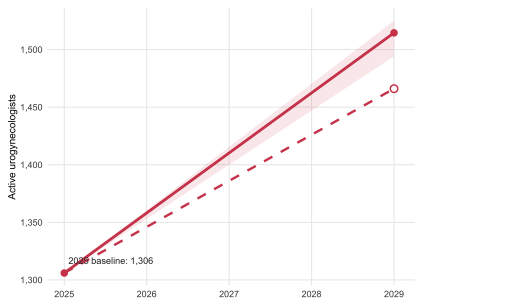

## Sensitivity Analyses

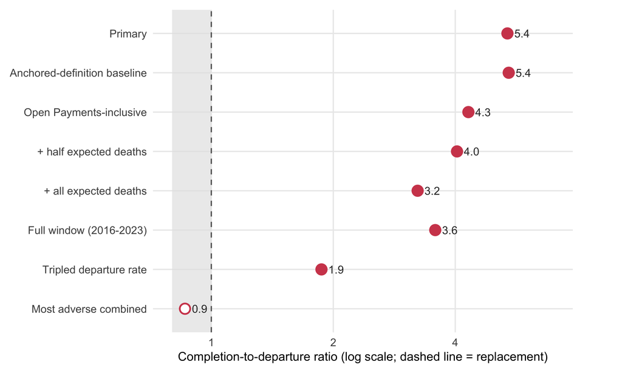

**Figure 2.** Selected urogynecology sensitivity analyses. Completion-to-departure ratio (log scale) from the primary analysis (filled point, top) to the most adverse combined scenario (outlined point, bottom); the dashed line marks one-for-one replacement and shading lies below it. Values are printed beside each point.

## Supply Relative to Demographic Need

In the exploratory 2030–2050 scenario extension, projected urogynecology supply (immediate-entry headcount) increased 84% (index 184, 2025 = 100), compared with 29% growth in women aged 65 years or older and 19% in women living with a pelvic floor disorder. Urogynecologists per 100,000 older women increased from 3.8 to 5.4, and women with a pelvic floor disorder per urogynecologist decreased from approximately 25,400 to 16,500 (Figure 3). Productivity-adjusted capacity also increased under the modeled assumptions, remaining above its 2025 value across the horizon. These are national aggregates under stable prevalence and care-seeking; they do not measure utilization or geographic access.

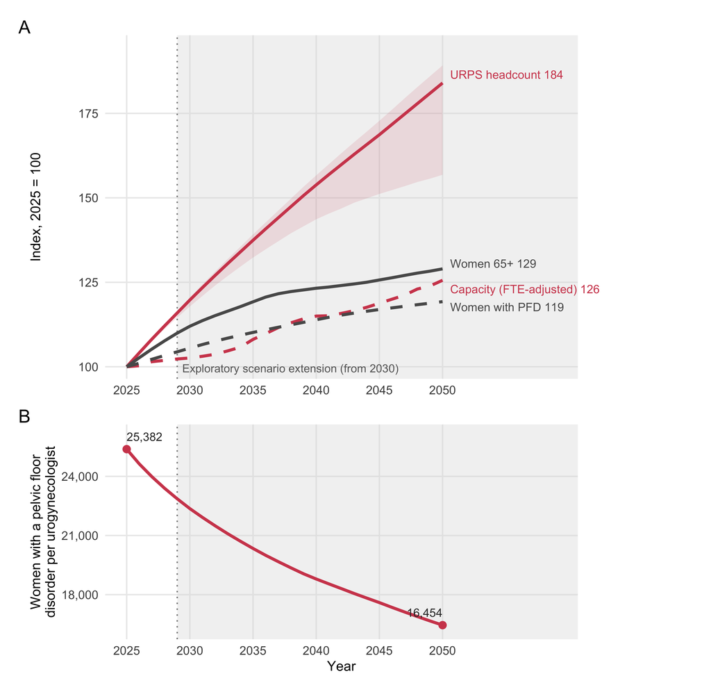

**Figure 3.** Urogynecology supply relative to demographic need, 2025–2050; the shaded region marks the exploratory scenario extension from 2030. (A) Immediate-entry supply headcount and productivity-adjusted capacity (accent color) and the two population-based need measures (gray), indexed to 2025 = 100, with 2050 endpoints labeled directly; the pink band is the 95% Monte Carlo uncertainty on projected headcount. (B) Women with a pelvic floor disorder per urogynecologist, with 2025 and 2050 values labeled. FTE, full-time equivalent; PFD, pelvic floor disorder.

An exploratory Medicare fee-for-service operative-workforce analysis could not distinguish true cessation of surgery from loss of Medicare visibility, so operative replacement was not estimated in the primary manuscript (Appendix S11).

# Discussion

In this national stock-and-flow analysis, recent fellowship completion exceeded projected near-term urogynecology departures. The completion-to-departure ratio was 5.4 for urogynecology and 7.1 for the gynecologic oncology comparator, both above one-for-one balance through 2029. In the exploratory extension to 2050, projected supply grew faster than both population-based measures of need, the number of women aged 65 years or older and the number living with a pelvic floor disorder, so projected per-capita coverage improved rather than declined. This improvement was contrary to the second part of our hypothesis, which anticipated that demographic growth would reduce per-capita coverage. Headcount replacement, however, is not workforce adequacy. These findings do not measure utilization, geographic access, clinical full-time-equivalent effort, or operative capacity.

The only prior national urogynecology projection compared a projected subspecialist headcount with the number of women living with pelvic floor disorders and reported a large, persistent burden per subspecialist, but it assumed fixed-age retirement and did not include the urology certification pathway or productivity-adjusted capacity.<sup>2</sup> We advance that work by counting an active both-pathway roster, estimating departure empirically from six administrative sources, using actual fellowship completions rather than program capacity, quantifying uncertainty, and reporting explicit demographic denominators. Our model-implied departure rates are consistent with the low-attrition position of gynecologic oncology in the largest national surgeon-attrition analysis, although differing definitions preclude a direct comparison.<sup>14</sup> Recent gynecologic oncology fellowship expansion has coincided with documented geographic maldistribution, which underscores that inflow-outflow balance and geographic distribution are distinct questions.<sup>20</sup>

Recent fellowship completion appears sufficient to offset projected national departures through 2029 under the modeled assumptions. Fellowship-capacity decisions should also consider geographic access, procedure-specific capacity, institutional needs, applicant supply, and the long-term training pipeline. National headcount balance does not resolve access, which depends on how a growing but geographically concentrated workforce is distributed; the share of United States counties without an obstetrician-gynecologist has remained near half despite stable-to-growing supply.<sup>21</sup> These results neither support contraction of fellowship positions nor imply that national headcount growth alone will improve local access.

Recent fellowship completion appears sufficient to offset projected national urogynecology departures through 2029 under the study assumptions. In the exploratory extension, projected supply increased faster than population-based measures of pelvic floor disorder need through 2050. These findings should not be interpreted as evidence of workforce adequacy: the analysis does not measure utilization, wait times, geographic access, clinical full-time-equivalent effort, or operative capacity, and the departure endpoint remains provisional. Future workforce planning should pair validated physician-level departure data with all-payer utilization, operative volume, and geographic-access measures.

# References

1.

Nygaard I, Barber MD, Burgio KL, et al. Prevalence of symptomatic pelvic floor disorders in US women. *JAMA*. 2008;300(11):1311-1316. doi:10.1001/jama.300.11.1311

2.

Brueseke TJ, Muffly T, Rayburn W, et al. Workforce analysis of female pelvic medicine and reconstructive surgery, 2015 to 2045. *Female Pelvic Medicine and Reconstructive Surgery*. 2016;22(5):385-389. doi:10.1097/SPV.0000000000000302

3.

Etzioni DA, Liu JH, Maggard MA, et al. The aging population and its impact on the surgery workforce. *Annals of Surgery*. 2003;238:170-177. doi:10.1097/01.SLA.0000081085.98792.3d

4.

Edwards JP, Datta I, Hunt JD, et al. A novel approach for the accurate prediction of thoracic surgery workforce requirements in Canada. *Journal of Thoracic and Cardiovascular Surgery*. 2014;148:7-12. doi:10.1016/j.jtcvs.2014.03.031

5.

Fraher EP, Knapton A, Sheldon GF, Meyer A, Ricketts TC. Projecting surgeon supply using a dynamic model. *Annals of Surgery*. 2013;257:867-872. doi:10.1097/SLA.0b013e31826fccfa

6.

Lee JT, Crettenden I, Tran M, et al. Methods for health workforce projection model: Systematic review and recommended good practice reporting guideline. *Human Resources for Health*. 2024;22:25. doi:10.1186/s12960-024-00895-z

7.

Rayburn WF, Xierali IM. Complexities of the obstetrician-gynecologist supply and demand. *Obstet Gynecol Clin North Am*. 2025;52(4):599-614. doi:10.1016/j.ogc.2025.07.001

8.

Shah A, Berkowitz ST, Tsui E, Gonzales JA, Crowell EL, Gangaputra S. Forecasting the workforce of uveitis specialists. *American Journal of Ophthalmology*. 2026;287:58-66. doi:10.1016/j.ajo.2026.03.021

9.

National Bureau of Economic Research. NPPES Cumulative Collection. Published online 2024.

10.

von Elm E, Altman DG, Egger M, et al. The Strengthening the Reporting of Observational Studies in Epidemiology (STROBE) statement: Guidelines for reporting observational studies. *Ann Intern Med*. 2007;147:573-577. doi:10.7326/0003-4819-147-8-200710160-00010

11.

Plaska SW, Maymi-Castrodad P, Gracely A, Daignault-Newton S, Clemens JQ, Ippolito GM. Practice patterns of surgeons seeking board certification in urogynecology and reconstructive pelvic surgery. *Neurourology and Urodynamics*. 2025;44(4):811-818. doi:10.1002/nau.70018

12.

American Board of Medical Specialties. Number of board-certified physicians by specialty. Published online 2024.

13.

Rotenstein LS, He Z, Dziura J, et al. Trends in and predictors of physician attrition from clinical practice across specialties: A nationwide, longitudinal analysis. *Annals of Internal Medicine*. 2025;178(12):1698-1708. doi:10.7326/ANNALS-25-00564

14.

Elemosho A, Chatzipanagiotou OP, Angeramo CA, et al. A national analysis of trends and factors associated with surgeon attrition in the united states. *Journal of the American College of Surgeons*. Published online 2026. doi:10.1097/XCS.0000000000001905

15.

Accreditation Council for Graduate Medical Education. *Data Resource Book, Academic Years 2020–2021 Through 2023–2024, Table d.5 (Residents and Fellows Completing Programs, by Specialty)*. Accreditation Council for Graduate Medical Education; 2024. https://www.acgme.org/about/publications-and-resources/graduate-medical-education-data-resource-book/

16.

Humphries LA, Shah DK, Shanks AL, et al. Decline in applicants to obstetrics and gynecology fellowships: Influence on match rates and competitiveness. *O&G Open*. 2026;3(1):e153. doi:10.1097/og9.0000000000000153

17.

Temkin SM, Chapman-Davis E, Nair N, et al. Creating work environments where people of all genders in gynecologic oncology can thrive: An SGO evidence-based review. *Gynecol Oncol*. 2022;164(3):473-480. doi:10.1016/j.ygyno.2021.12.032

18.

Muffly T. Urogynecology workforce supply-and-demand explorer: An interactive web application. Published online 2026.

19.

R Core Team. *R: A Language and Environment for Statistical Computing*. R Foundation for Statistical Computing; 2023. https://www.R-project.org/

20.

Holtzman S, Myers ER, Havrilesky LJ, et al. Gynecologic oncology fellowship trends: Supply outpacing demand, geographical maldistribution. *Gynecol Oncol*. 2025;202:162-166. doi:10.1016/j.ygyno.2025.09.003

21.

Chen V, Ying X, Majdinasab E, Theiler RN. Geographic disparities in obstetric care access in the united states. *Obstet Gynecol*. 2026;147(3):422-424. doi:10.1097/AOG.0000000000006069